# Dollar Cost Averaging is Good For Your Emotions

#### Motivation

I’ve been following a number of blogs (mrmoneymustache, etc) and posts on /r/personalfinance, /r/financialindependence, etc, and learning enormous amounts about investing. One thing I constantly hear is that dollar cost averaging is an inefficient way to invest, and that you should always put your money in immediately. In contrast, many people end up doing dollar cost averaging, where they put in a bit of their money at a time. It’s pretty well established that investing all at once is the optimal choice (on average), but it’s less obvious why we intuitively feel that dollar cost averaging will be the less gut-wrenching option. I’m a fan of simulations so what I’m going to do here is simulate the success of DCA vs. 100% immediate investment, and then look at how “gut-wrenching” each approach is! Let’s dive in!

### Step 1: Convince ourselves that the market trends up, and the trend is exponential

I have here, courtesy of yahoo, the last 66 years of the S&P 500’s history. I’m going to go ahead load the data, which has daily prices for every business day and show you that they do indeed follow an exponential curve.

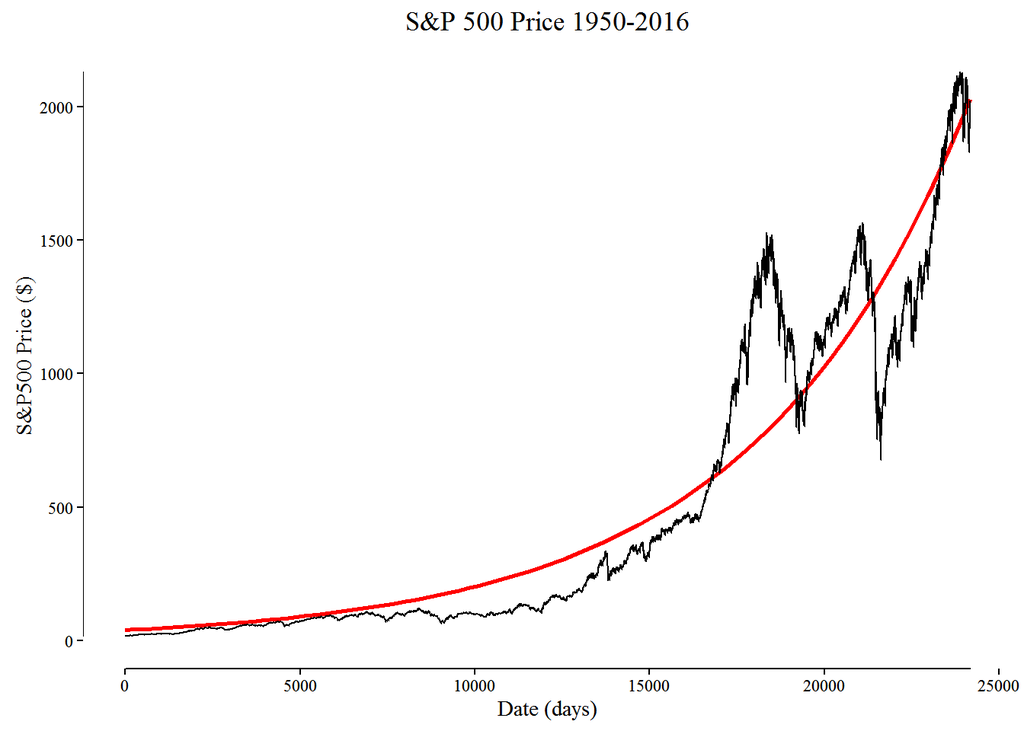

I didn’t bother to fit the exponential curve very well, as you can tell the curve isn’t steep enough. But that aside, it’s obvious that at basically any point in time (except in the last few hundred days) it’s always better to invest all your money at once, because eventually it will go up.

We can be a bit more precise though by breaking up our dataset into chunks of “X” years, offset by a month between each dataset, and then looking at how often investments go up over that period vs. going down. This is basically what “Risk” means in terms of investing.

I’ll generate two big datasets, one sampled every month and going out 5 years, and one sampled every month going out 30 years.

Now sample from our dataset.

```r
data5 = sample(5,data)
data30 = sample(30,data)
```

And plot! The Y axis here is normalized so that it starts at 100%, otherwise it wouldn’t be possible to compare different time periods.

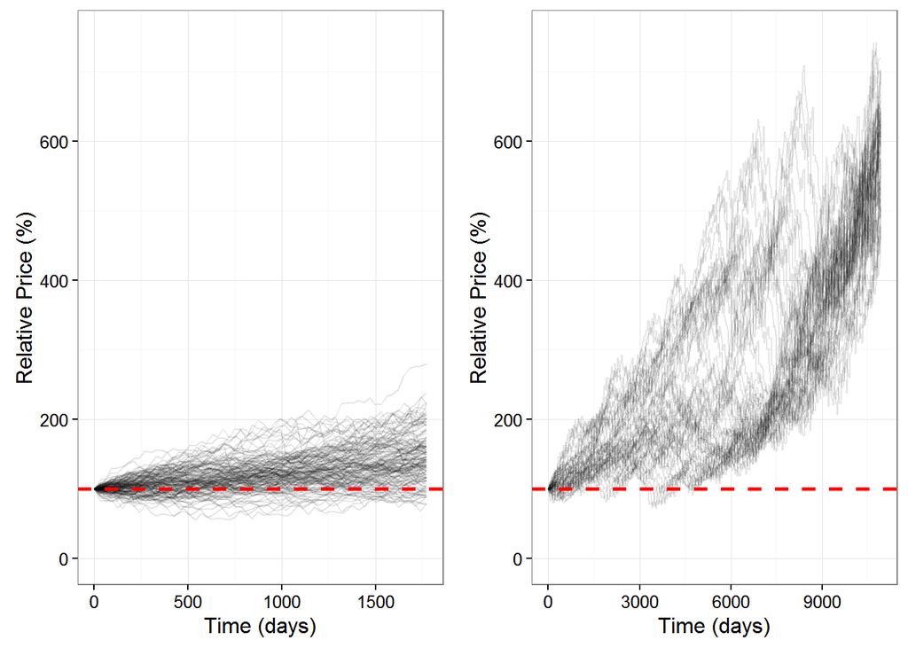

It looks like on average over 5 years the S&P 500 goes up, although ocassionally it seems to go down a bit and sometimes it seems to be very flat. Over 30 years there’s no question, it always goes up! So at this point, I am convinced, the market goes up.

### Step 2: Compare the success of dollar cost averaging vs. immediate initial investment

We’re going to imagine we’re an investor who wants to invest X dollars. We’ll try two things: either we invest X all at once (1 event) or we will split X into 2, 3, 4, or 5 equal parts, and invest them every Y days. In this case, Y will be every 200 days (this is a bit arbitrary, it could be any number).

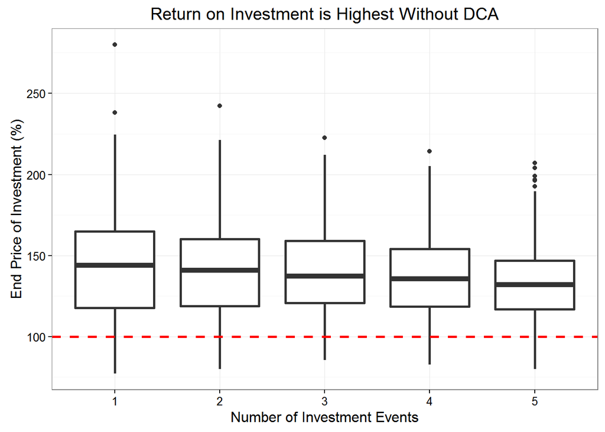

Okay, as expected, when we split our money up and invest some of it later on we end up doing worse. Not a huge surprise! We knew that the market was mostly exponential, so putting your money in later is on average a bad idea. So I’ll accept that fact.

### Step 3: What happens to those gut-wrenching emotions?

Okay, here’s the punchline! We don’t really care how well the investments do, we know DCA hurts us. But what about our gut! I want to feel *happy* about my investments! So let’s imagine that we’re a very simple investor who checks his investments once a month. If our investments went up since last month, we are happy (+1)! If our investments went down, we’re unhappy (-1). We’re simply going to look now at how much total happiness we have depending on how much dollar cost averaging we do.

Some quick examples to be clear how our toy investor works. Note that at the end of the day all of these investments have the same value (150 or 50% increase over original), if someone were to invest entirely on day 1 they would come out with the same total sum of money! But–they would be differently happy:

```r
emote(c(100,120,130,140,150)) # continuously increasing, most happiness
```

```
## [1] 4
```

```r
emote(c(100,120,110,140,150)) # one dip, less happy
```

```
## [1] 2
```

```r
emote(c(100,0,-100,-200,150)) # many dips, very unhappy
```

```
## [1] -2
```

```r
emote(c(100,600,-500,0,150)) # large variability, this model doesn't care
```

```
## [1] 2
```

Okay so clearly we are sensitive to extended periods of time where things go downhill, anything that reduces that possibility and smooths out the ride will make us more happy. Does DCA do that for us? (One way to think about this is to think: what if our DCA happened during a downturn? Our initial investment might still be down, but the later investment should ‘soften the blow’ so to speak.) Let’s check:

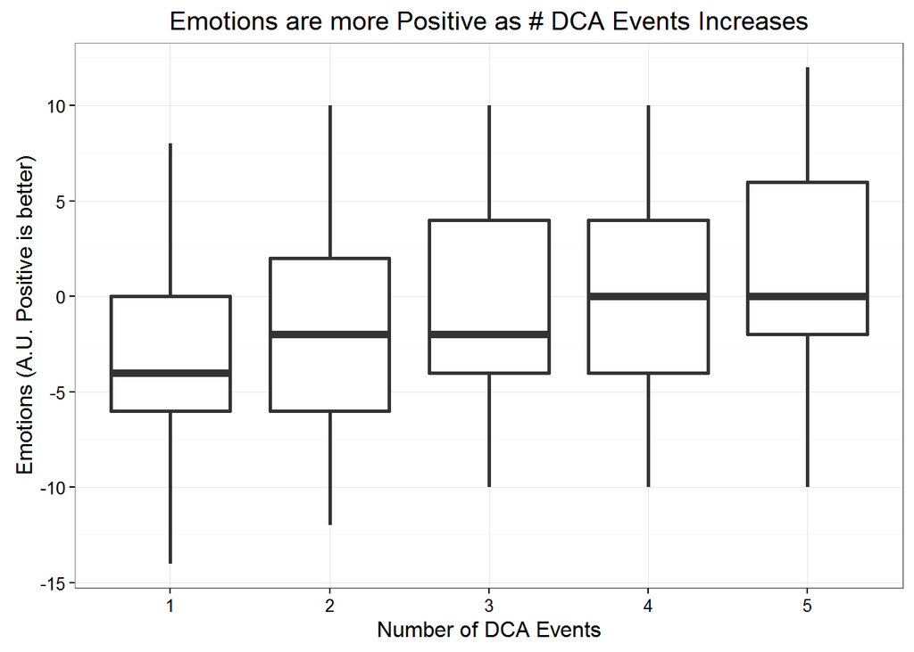

Surprise surprise! Or not! DCA does in fact save you from those gut-wrenching emotions! The more dollar cost averaging you do (remember these investments are far apart) the less terrified you will be! In short, DCA narrows the expected range of returns. This is no different than investing in bonds in lieu of stocks, in the short term DCA reduces the likelihood of having negative returns, in the long run it costs you.

#### Conclusions

So there’s the simple truth–by simulating a simple model of an investor we can see that dollar cost averaging is the logical thing to do if you’re more worried about your emotions–but the wrong thing to do when you’re more worried about your investments. If you’re the kind of investor who constantly checks their phone to see how their investments are doing each day, you will definitely benefit from the peace of mind of knowing that with DCA you will end up less stressed out. If you’re the kind of person who invests and forgets–put it all in today! Thanks for reading, I hope you found this interesting!

There are plenty of caveats and this is just one simulation only using US data, but it's a fun simple exercise :). Everything is hosted at github.com/dbirman/invest, written in R in RStudio.